# Data Preprocessing Notes

Imad Ali

May 17, 2016

## Basic Preprocessing

Some of the basic preprocessing techniques include **zero centering** the data (also known as de-meaning the data) and **normalizing** the data, which involves dividing each centered variable by its corresponding standard deviation, making the data scale invariant.

```r
# raw data
X <- rmvnorm(1000, mean = c(2,2), sigma = cbind(c(1,0.9),c(0.9,2)))
# de-mean (i.e. zero mean transform, zero centering)
X_dm <- cbind(X[,1]-mean(X[,1]), X[,2]-mean(X[,2]))
# normalize (i.e. scale invariant transform)
X_dms <- cbind(X_dm[,1]/sd(X_dm[,1]), X_dm[,2]/sd(X_dm[,2]))
```

The plots below illustrate these two transformations on randomly generated data from the bivariate normal distribution.

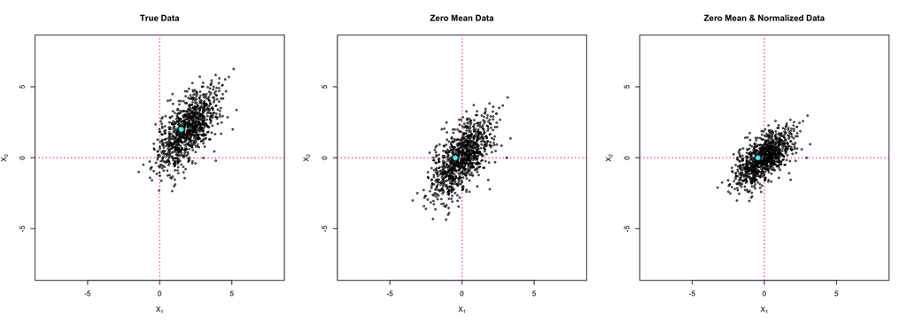

Another scale invariant transform is to **log transform** the data. This transformation is also useful if you want to to apply a model that presupposes a linear relationship (e.g. least squares) in the data. Given the nature of the natural logarithmic function, the log of a negative number is undefined and the log of zero (as a limit) approaches negative infinity. Before applying this transformation it’s important to condsider these restrictions with regard to the data being used. In the random data generated here we cannot apply such a transformation.

## Eigendecomposition to Singular Value Decomposition

In order to understand what singlular value decomposition (SVD) is doing we have to understand its predecessor eigendecomposition. Eigendecomposition says that if you have a matrix $A$ then there are some vectors $x$ that point in the same direction as $Ax$. These vectors are called **eigenvectors**. When we perform the multiplication $Ax$ we have essentially scaled the vector $x$. It is possible to find some value $\lambda$ that satisfies the equation,
$$Ax=\lambda x$$
The value(s) $\lambda$ are referred to as **eigenvalues** and represents what the matrix $A$ has done to $x$. Specifically $\lambda$ will tell you how much $A$ expanded/contracted the vector $x$ and/or whether it has reflected the direction $x$. Note that the set of eigenvectors corresponding to a symmetric matrix will be orthogonal.

SVD is just a generalization of eigendecomposition to non-square matrices. Let $V$ be the matrix that contains the orthanormal bases in the row space $\mathbb{R}^n$ and let $U$ be the matrix that contains the orthonormal bases in the column space $\mathbb{R}^m$. Eigendecomposition is a special case of SVD where $n=m$, and this will result in matrices $V$ and $U$ being equal. The diagonal matrix $\Sigma$ explains how much $AV$ transforms $V$ to give the matrix $U$. In other words, we have the following equation that is analogous to eigenvector/eigenvalue relationship given above,
$$AV=U\Sigma \\
\Leftrightarrow \\
A=U\Sigma V^\top$$

Formally, the values in $\Sigma$ that are different from zero are known as singular values, $Ui$ refers to the left singular vectors and $V$ refers to the right singular vectors.

```r
# Create the covariance matrix
cov <- cov(X_dm)
# Apply SVD decomposition
# decomp$d => singular values, decomp$u => left singluar vectors, decomp$v => right singular vectors
decomp <- svd(cov)
# Project zero centered data onto the eigenvectors (decorrelate the data)
X_svd <- X_dm%*%decomp$u
# Whitening (divide the the eigenvalues = sqrt(singular values))
X_w <- cbind(X_svd[,1]/sqrt(decomp$d+1e-5)[1], X_svd[,2]/sqrt(decomp$d+1e-5)[2])
```

The plots below illustrate these transformations using the same bivariate normal data above. In order to decorrelate the data we found the eigenvectors of the covariance matrix using SVD, and then projected the zero centered data onto those eigenvectors (here we use eigenvectors synonomously with right singular vectors). The `svd()` function in R returns orthonormal eigenvectors. This means we can consider the eigenvectors as a bases as we would consider the rectangular coordinate bases $(1,0)$ and $(0,1)$. Geometrically, projecting the the data onto the eigenvectors of the covariance matrix rotates the data so that the bases are now represented by the eigenvectors.

Note that just because the axes appear to be the same does not mean that they are. Since the data has been rotated, the axes have to be scaled appropriately in order to account for this transformation.

Specifically, given the data generated, projecting the data onto the eigenvectors rotated the data clockwise and then reflected the data with respect to the y-axis. We can see this by tracking the eigenvectors (plotted in green) from the *True Data* plot to the *Decorrelation* plot. Going from *Decorrelation* to *Whitening* notice that the scale invariant transformation of dividing the projection by the eigenvalues has slightly stretched the data along the y-axis and sightly compressed the data along the x-axis.

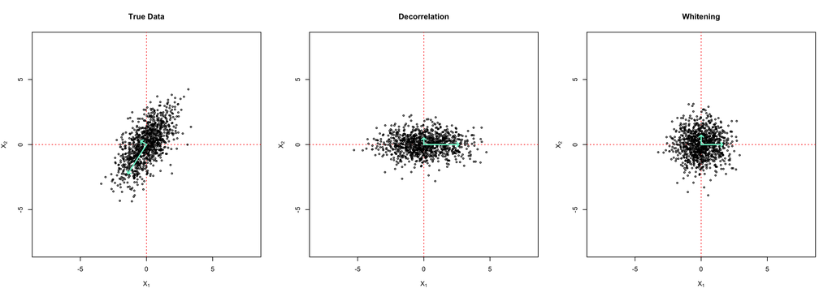

It is important to note that the magnitude of the singular values (i.e. eigenvalues) is related to how much variation there is in the data along the corresponding dimension. The right singular vectors plotted in the *True Data* plot above have been scaled by the square root of their corresponding singular values. From visual inspection, the variation is greatest along the vertical axis. This is reflected in the singular value (in $\Sigma$) being larger for that particular right singular vector (in $V$). This is a particularly useful feature if we are dealing with many predictors. By ranking the singular values, SVD allows us to only focus on the variables that explain the most variation in the data, which provides us with an informative way to reduce the dimensionality of the space we are working in.

```r
# Singular values
decomp$d
```

```
## [1] 2.6432293 0.5188111
```

```r
# Right singular vectors
decomp$v
```

```
##            [,1]       [,2]
## [1,] -0.5308763 -0.8474493
## [2,] -0.8474493  0.5308763
```

See the GitHub repository for the complete code `preprocessing_notes.R`: https://github.com/imadmali/ml-preprocessing. Stanford’s CS231n course notes provide an overview of data preprocessing in Python in the context of neural networks [here](http://cs231n.github.io/neural-networks-2/). The American Mathematical Society has a nice feature column [here](http://www.ams.org/samplings/feature-column/fcarc-svd) that builds the intuition of SVD using a 2x2 matrix example. For further information about the theory behind eigendecomposition and SVD, Gilbert Strang’s [Introduction to Linear Algebra](http://ocw.mit.edu/courses/mathematics/18-06-linear-algebra-spring-2010/readings/) is a useful resource.